### CS 4840 Intro Machine Learning - Lab Assignment 1

# End-to-End Machine Learning Pipeline: A Linear Regression Problem

## This is only for undergraduate students in CS 4840

### 1. Overview

The learning objective of this lab assignment is for students to understand the end-to-end machine learning pipeline, including how to load the data from csv file to DataFrame, how to take a quick look at data structure and statistics, how to visualize the data to gain insights, how to deal with missing features and categorical features, and how to scale feature values. As we use diabetes data as an example, this lab assignment also includes how to build a linear regression model to predict the diabetes progression in one year, and how to evaluate the regression results.

#### Lecture notes.

Detailed coverage of these topics can be found in the following:

Terms and Principles of Machine Learning

Model Training using Gradient Descent

Feature Preprocessing

#### Code demonstrations.

Code 2023-09-11-M-Model Training using Gradient Descent-1.ipynb

Code-2023-09-13-W-Model Training using Gradient Descent-2.ipynb

Code-2023-09-18-M-Feature Preprocessing.ipynb

### 2. Submission

You need to submit a detailed lab report with code, running results, and answers to the questions. If you submit a jupyter notebook (“Firstname-Lastname-4840-Lab1.ipynd”), please fill in this file directly and place the code, running results, and answers in order for each question. If you submit a PDF report (“Firstname-Lastname-4840-Lab1.pdf”) with code file (“Firstname-Lastname-4840-Lab1.py”), please include the screenshots (code and running results) with answers for each question in the report.

### 3. Questions (50 points)

For this lab assignment, you will be using the `Diabetes dataset` to complete the following tasks and answer the questions. Diabetes dataset has different features and a target label. You will use these features to build a linear regression model to predict the diabetes disease progression one year. First, please place `diabetes.csv` and your notebook/python file in the same directory, and load the data into DataFrame.

```python
import os
import pandas as pd
import numpy as np
import matplotlib.pyplot as plt

#Please place diabetes.csv and your notebook/python file in the same directory; otherwise, change DATA_PATH
DATA_PATH = ""

def load_diabetes_data(diabetes_path=DATA_PATH):
    csv_path = os.path.join(diabetes_path, "diabetes.csv")
    return pd.read_csv(csv_path)

diabetes = load_diabetes_data()
```

#### Question 1 (5 points):

Please print out the information/statistics of diabetes DataFrame in function `answer_one( )`, and describe: how many records does the diabetes dataset have? Except for the target label `diabetes_progression_one_year`, how many features does the diabetes dataset have? What are these features? Among these features, which feature is non-numerical (categorical) and which feature has missing values?

```python
def answer_one(diabetes):
    columnNums = diabetes.shape[1]-1
    #Please complete print() using diabetes(DataFrame)'s information API
    diabetes = diabetes
    print("∎Print out the information/statistics : "  )
    diabetes.head()
    diabetes.info()
    print("\n")
    print("∎How many records does the diabetes dataset have?  ")
    print("There are "+ str(diabetes.shape[0]) + " reords.")
    print("\n")
    print('∎How many features does the diabetes dataset have? except for the "diabetes_progression_one_year" label.'  )
    print("There are " + str(columnNums) +" features.")
    print("\n")
    print("∎What are these features?")
    column_names = diabetes.columns[:-1]
    print(f"Features names: {', '.join(column_names)}")
    print("\n")
    print("∎The categorical features:")
    categorical_columns = diabetes.select_dtypes(include=['object']).columns
    print(f"{', '.join(categorical_columns)}")
    print("\n")
    print("∎Which feature has missing values?")
    missing_columns = diabetes.columns[:-1][diabetes[diabetes.columns[:-1]].isnull().any()]
    print(f"{', '.join(missing_columns)}")


#Run your function in the cell to return the result
answer_one(diabetes)
```

```
∎Print out the information/statistics :
<class 'pandas.core.frame.DataFrame'>
RangeIndex: 442 entries, 0 to 441
Data columns (total 11 columns):
 #   Column                         Non-Null Count  Dtype
---  ------                         --------------  -----
 0   age                            442 non-null    int64
 1   gender                         442 non-null    object
 2   bmi                            442 non-null    float64
 3   blood_pressure                 442 non-null    float64
 4   total_serum_cholesterol        442 non-null    int64
 5   low_density_lipoproteins       442 non-null    float64
 6   high_density_lipoproteins      442 non-null    float64
 7   total_cholesterol              431 non-null    float64
 8   serum_triglycerides_level      442 non-null    float64
 9   blood_sugar_level              442 non-null    int64
 10  diabetes_progression_one_year  442 non-null    int64
dtypes: float64(6), int64(4), object(1)
memory usage: 38.1+ KB


∎How many records does the diabetes dataset have?
There are 442 reords.


∎How many features does the diabetes dataset have? except for the "diabetes_progression_one_year" label.
There are 10 features.


∎What are these features?
Features names: age, gender, bmi, blood_pressure, total_serum_cholesterol, low_density_lipoproteins, high_density_lipoproteins, total_cholesterol, serum_triglycerides_level, blood_sugar_level


∎The categorical features:
gender


∎Which feature has missing values?
total_cholesterol
```

#### Answer 1:

How many records does the diabetes dataset have?  
There are 442 reords.

How many features does the diabetes dataset have? except for the "diabetes_progression_one_year" label. There are 10 features.

What are these features? Features names: age, gender, bmi, blood_pressure, total_serum_cholesterol, low_density_lipoproteins, high_density_lipoproteins, total_cholesterol, serum_triglycerides_level, blood_sugar_level

The categorical features: gender

Which feature has missing values? total_cholesterol

#### Question 2 (5 points):

Please visualize the data by plotting a histogram for each numerical feature in function `answer_two( )`, and describe the scale and distribution characteristics of these features. In particular, please describe your observation on the data distribtuion for the feature `total_cholesterol`.

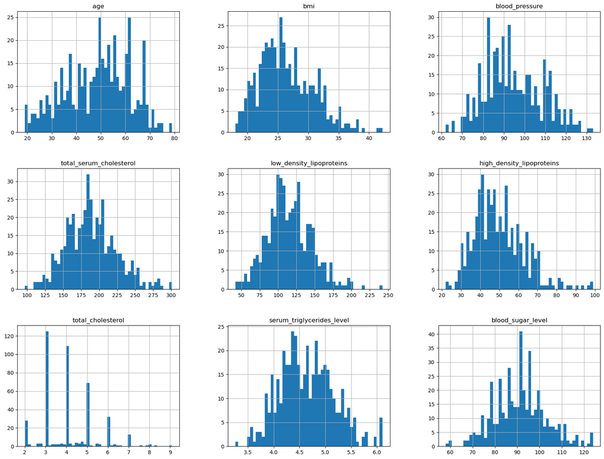

```python
from pandas.plotting import scatter_matrix

def answer_two():
    #Please complete the function using diabetes(DataFrame)'s histogram API
    diabetes.drop(columns=['diabetes_progression_one_year']).hist(bins=50, figsize=(20,15))
    plt.show()


#Run your function in the cell to return the result
answer_two()
```

#### Answer 2:

Describe the scale and distribution characteristics of each features:

X-axis represents the values, Y-axis represents the frequency.

total_serum_cholesterol: Scale: range from approximately 100 to 300. Mode: centered around the value of 175-180 Skewness: slightly right-skewed

#### Question 3 (5 points):

Please calculate feature correlation matrix and print out the feature correlation information for `diabetes_progression_one_year` in function `answer_three( )`, and describe: except for `diabetes_progression_one_year` itself, which feature has the strongest correlation with `diabetes_progression_one_year`, and which feature has the weakest correlation with `diabetes_progression_one_year`? Why?

```python
def answer_three():
    #Please complete the function using diabetes(DataFrame)'s correlation API
    corr_matrix = diabetes.drop(columns=['gender']).corr()
    #Please print out the feature correlation information for diabetes_progression_one_year from corr_matrix in the descending order
    print(corr_matrix["diabetes_progression_one_year"].sort_values(ascending=False))


#Run your function in the cell to return the result
answer_three()
```

```
diabetes_progression_one_year    1.000000
bmi                              0.586450
serum_triglycerides_level        0.565883
blood_pressure                   0.441482
total_cholesterol                0.425980
blood_sugar_level                0.382483
total_serum_cholesterol          0.212022
age                              0.187889
low_density_lipoproteins         0.174054
high_density_lipoproteins       -0.394789
Name: diabetes_progression_one_year, dtype: float64
```

#### Answer 3:

Because correlation values range between -1 and 1. If close to 1, that means a strong positive correlation. If close to -1,that means a strong negative correlation. If close to 0,that means little to no correlation.

#### Question 4 (3 points):

From question 3, you can figure out the feature (strongest_feature) that has the strongest correlation with `diabetes_progression_one_year`, and the feature (weakest_feature) that has the weakest correlation with `diabetes_progression_one_year`. Please fill in feature name in the option `x=" "` of plot function in `answer_four( )` to plot the data distribution between the strongest/weakest feature and `diabetes_progression_one_year`. Please describe your observations on these two plots: how the data distribution looks like for each plot, and if the data distribution conforms to the obtained feature correlation?

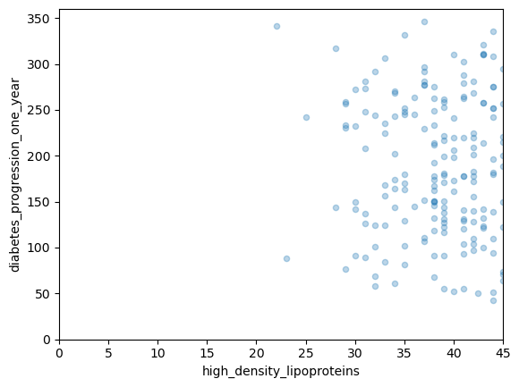

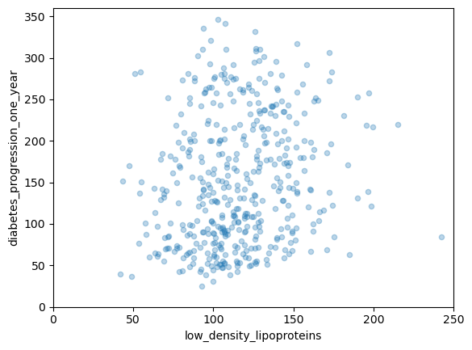

```python
def answer_four():
    #Please set option x=" " using the name of strongest_feature
    diabetes.plot(kind="scatter", x="high_density_lipoproteins", y="diabetes_progression_one_year", alpha=0.3)
    plt.axis([0, 45, 0, 360])

    #Please set option x=" " using the name of weakest_feature
    diabetes.plot(kind="scatter", x="low_density_lipoproteins", y="diabetes_progression_one_year", alpha=0.3)
    plt.axis([0, 250, 0, 360])

    plt.show()

#Run your function in the cell to return the result
answer_four()
```

#### Answer 4:

Second Plot: The data points are densely packed around the 50 to 150 range for low_density_lipoproteins and the 50 to 250 range for diabetes_progression_one_year. The plot show no trend in either positive or negative direction.

#### Devide the DataFrame into features `diabetes_features` and labels `diabetes_labels`

```python
diabetes_labels = diabetes["diabetes_progression_one_year"].copy() # use diabete_progression_one_year as label
diabetes_features = diabetes.drop("diabetes_progression_one_year", axis=1) # drop diabete_progression_one_year
```

#### Question 5 (5 points):

As `total_cholesterol` has missing values, please use its median number to set those missing feature values in function `answer_five( )`. After processing, please describe if there are still data records with NULL feature values by using the given code line.

```python
def answer_five():
    diabetes_features = diabetes.drop("diabetes_progression_one_year", axis=1)
    #Please operate on diabetes_features to set the missing "total_cholesterol" values using median
    median = diabetes_features["total_cholesterol"].median()
    diabetes_features["total_cholesterol"].fillna(median, inplace=True)

    # Checking if there are still NULL values
    print( "There is :" + str(diabetes_features["total_cholesterol"].isnull().sum()) + " NULL value")

#Run your function in the cell to return the result
answer_five()
```

```
There is :0 NULL value
```

```python
#Check if there are still records with null feature values
#Empty DataFrame means no record with null feature values
print(diabetes_features[diabetes_features.isnull().any(axis=1)].head())
```

[output not shown]

#### Devide features into numerical part `diabetes_num` and categorical part `diabetes_cat`

```python
#diabetes_num only includes the numerical features without gender
diabetes_num = diabetes_features.drop("gender", axis=1)

#diabetes_cat only includes the categorical feature gender
diabetes_cat = diabetes_features[["gender"]]
print(diabetes_cat["gender"].value_counts())
```

[output not shown]

#### Question 6 (5 points):

As gender contains categories without order, please convert these categoties into numbers directly using `OrdinalEncoder` in function `answer_six( )`, and print out gender values after conversion.

```python
from sklearn.preprocessing import OrdinalEncoder

def answer_six():
    diabetes_features = diabetes.drop("diabetes_progression_one_year", axis=1)
    diabetes_cat = diabetes_features[["gender"]]
    ordinal_encoder = OrdinalEncoder()
    #Please complete the code line using fit_transform API to operate on diabetes_cat
    diabetes_cat_encoded = ordinal_encoder.fit_transform(diabetes_cat)

    return diabetes_cat_encoded

#Run your function in the cell to return the result
diabetes_cat_encoded = answer_six()
print(diabetes_cat_encoded)
```

```
[[0.]
 [1.]
 [0.]
 [1.]
 [1.]
 [1.]
 [0.]
 [0.]
 [0.]
 [1.]
 [1.]
 [0.]
 [1.]
 [0.]
 [1.]
 [0.]
 [1.]
 [0.]
 [1.]
 [1.]
 [1.]
 [0.]
 [1.]
 [0.]
 [1.]
 [0.]
 [1.]
 [1.]
 [1.]
 [0.]
 [1.]
 [1.]
 [0.]
 [1.]
 [1.]
 [0.]
 [1.]
 [1.]
 [0.]
 [0.]
```

[output cut: 387 more lines]

```
 [0.]
 [0.]
 [1.]
 [1.]
 [0.]
 [1.]
 [1.]
 [1.]
 [1.]
 [1.]
 [0.]
 [0.]
 [0.]
 [1.]
 [1.]]
```

#### Question 7 (5 points):

```python
from sklearn.preprocessing import StandardScaler

def answer_seven():
    diabetes_features = diabetes.drop("diabetes_progression_one_year", axis=1)
    diabetes_num = diabetes_features.drop("gender", axis=1)
    ordinal_encoder = OrdinalEncoder()
    std_scaler = OrdinalEncoder()
    #Please complete the code line using fit_transform API to operate on diabetes_num
    diabetes_num_scaled= std_scaler.fit_transform(diabetes_num)

    return diabetes_num_scaled

#Run your function in the cell to return the result
diabetes_num_scaled = answer_seven()
print(diabetes_num_scaled)
```

```
[[ 40. 130.  60. ...  22.  90.  22.]
 [ 29.  31.  34. ...   9.  13.   4.]
 [ 53. 117.  46. ...  22.  69.  20.]
 ...
 [ 41.  64.  58. ...  18.  26.  30.]
 [ 17. 112.  51. ...  40. 125.  20.]
 [ 17.  11.   6. ...   9.  61.  27.]]
```

#### Concatenate `diabetes_num_scaled` and `diabetes_cat_encoded` into the final features `X`

```python
#Diabetes features

diabetes_features = diabetes.drop("diabetes_progression_one_year", axis=1)
median = diabetes_features["total_cholesterol"].median()
diabetes_features["total_cholesterol"].fillna(median, inplace=True)

X = np.concatenate((diabetes_num_scaled, diabetes_cat_encoded), axis=1)

#Diabetes labels
diabetes_labels = diabetes["diabetes_progression_one_year"].copy()
y = diabetes_labels.to_numpy()

print(X.shape)
print(y.shape)
```

```
(442, 10)
(442,)
```

#### Question 8 (5 points):

Please use `train_test_split` to split `X` and `y` into training and test sets `(X_train, X_test, y_train, and y_test)` in function `answer_eight()`, and describe the shape of `X_train`, `X_test`, `y_train`, and `y_test`, respectively.

**Set `random_state=42` and `test_size=0.2` in `train_test_split` to make sure 80% of your dataset is used for training and 20% for testing**

```python
from sklearn.model_selection import train_test_split


X_train, X_test, y_train, y_test = train_test_split(X, y, test_size=0.2, random_state=42)

def answer_eight():
    #Please complete the code line using train_test_split


    return X_train, X_test, y_train, y_test

#Run your function in the cell to return the result
X_train, X_test, y_train, y_test = answer_eight()
print("X_train shape :" + str(X_train.shape))
print("X_test shape:" + str(X_test.shape))
print("y_train shape:" + str(y_train.shape))
print("y_test shape:" + str(y_test.shape))
```

```
X_train shape :(353, 10)
X_test shape:(89, 10)
y_train shape:(353,)
y_test shape:(89,)
```

#### Answer 8:

X_train shape :(353, 10) it has 353 rows,10 columns y_train shape:(353,) it has 353 rows ,corresponding to the 353 samples in X_train.

#### Question 9 (5 points):

Please use `LinearRegression` to build a linear regression model with `X_train` and `y_train` in function `answer_nine( )`.

```python
from sklearn.linear_model import LinearRegression
import numpy as np
import pandas as pd

def answer_nine():

    lin_reg = LinearRegression()

    # Check if X_train is a numpy array
    if isinstance(X_train, np.ndarray):
        # Get indices of rows without NaNs
        mask = ~np.isnan(X_train).any(axis=1)
        X_train_clean = X_train[mask]
        y_train_clean = y_train[mask]
    else:
        # Assuming X_train is a pandas DataFrame
        X_train.dropna(inplace=True)
        y_train_clean = y_train[X_train.index]
        X_train_clean = X_train

    lin_reg.fit(X_train_clean, y_train_clean)

    return lin_reg



lin_reg = answer_nine()
```

#### Question 10 (5 points):

Please evaluate the linear regression model by calculating root mean square error (RMSE) and mean absolute error (MAE) between the true labels `y_test` and predictions `y_predict` in function `answer_ten( )`, and describe the results of RMSE and MAE.

```python
from sklearn.metrics import mean_squared_error
from sklearn.metrics import mean_absolute_error

# Handle missing values if X_test is a numpy array
mask = ~np.isnan(X_test).any(axis=1)
X_test_clean = X_test[mask]
y_test_clean = y_test[mask]

y_predict = lin_reg.predict(X_test_clean)

def answer_ten():
    # Get mean square error using mean_squared_error API
    mse = mean_squared_error(y_test_clean, y_predict)
    rmse = np.sqrt(mse)

    # Get mean absolute error using mean_absolute_error API
    mae = mean_absolute_error(y_test_clean, y_predict)

    return rmse, mae

# Run your function to return the result
rmse, mae = answer_ten()
print("Root Mean Square Error (RMSE):", rmse)
print("Mean Absolute Error (MAE):", mae)
```

```
Root Mean Square Error (RMSE): 52.4273778498403
Mean Absolute Error (MAE): 41.55531907915784
```

#### Answer 10:

Root Mean Square Error (RMSE): 52.4273778498403 Mean Absolute Error (MAE): 41.55531907915784

#### Question 11 (2 points):

Please use the following given code to plot the true labels `y_test` (blue) and predictions `y_predict` (red), and according to RMSE, MAE, and the plot, describe if your linear regression model trained on `X_train` and `y_train` makes good predictions and explain why.

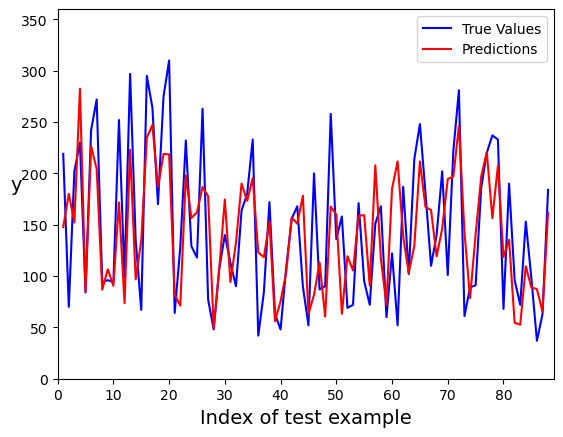

```python
indices = np.arange(1, len(y_predict) + 1)
plt.plot(indices, y_test_clean, "b-",label="True Values")
plt.plot(indices, y_predict, "r-",label="Predictions")
plt.xlabel("Index of test example", fontsize=14)
plt.ylabel("y", fontsize=14, rotation=0)
plt.axis([0, len(y_predict) + 1, 0, 360])
plt.legend()
plt.show()
```